# R Notebook

```r
library(tidyverse)
library(janitor)
library(lubridate)
library(corrr)
```

```r
wh_visitor_data <- read_csv("data/cleaned_OPENREFINE.csv")
```

Let’s take a quick look at the data now that we’ve changed these columns into dates.

```r
glimpse(wh_visitor_data)
```

```
Rows: 847,371
Columns: 32
$ namelast                <chr> "AAKHUU", "AASSAR", "ABALOS", "ABARCAR", "ABBOTT…
$ namelast_clean          <chr> "AAKHUU", "AASSAR", "ABALOS", "ABARCAR", "ABBOTT…
$ namefirst               <chr> "BOLORMAA", "MIA", "JANILA", "KARA", "NICOLAS", …
$ namemid                 <chr> "N", "L", "L", "N", "P", "C", "R", "S", "C", "E"…
$ uin                     <chr> "U38116", "U37794", "U38186", "U37879", "U36630"…
$ bdgnbr                  <dbl> NA, NA, NA, NA, NA, NA, NA, NA, NA, NA, NA, NA, …
$ access_type             <chr> "VA", "VA", "VA", "VA", "VA", "VA", "VA", "VA", …
$ toa                     <dttm> NA, 2021-12-17 12:23:00, NA, 2021-12-19 17:25:0…
$ poa                     <chr> NA, NA, NA, NA, NA, NA, NA, NA, NA, NA, NA, NA, …
$ tod                     <dttm> NA, NA, NA, NA, NA, NA, NA, NA, NA, NA, NA, NA,…
$ pod                     <chr> NA, NA, NA, NA, NA, NA, NA, NA, NA, NA, NA, NA, …
$ appt_made_date          <dttm> 2021-12-18 11:13:00, 2021-12-17 11:55:00, 2021-…
$ appt_start_date         <date> 2021-12-19, 2021-12-17, 2021-12-19, 2021-12-19,…
```

[output cut: 19 more lines]

There are a lot of columns here that might not be particularly interesting or useful. We should probably get rid of x28 and x29, caller room, appt cancel date, terminal suffix, and any others that aren’t valuable. There are a lot of NAs in here where dates should go. Also, the dates and times aren’t always written the same way. Is that going to cause us problems? We should probably check with Derek about that.

Let’s see when the most popular day for visiting was. To do that, first we’re going to create new columns with only the dates.

```r
###note - we were having problems with this so I asked chatgpt: how do I make a new column with just the date from a column that includes date and time using lubridate and the tidyverse? it told me to do mutate(toa_date = ymd_hms(toa) %>% date())

wh_visitor_data <- wh_visitor_data |>
  mutate(toa_date = ymd_hms(toa) |> date())
wh_visitor_data |>
  group_by(toa_date) |>
  summarize(count=n()) |>
  arrange(desc(count))
```

| toa_date | count |
| --- | --- |
|  | 264294 |
| 2022-12-18 | 5704 |
| 2022-12-03 | 5687 |
| 2022-12-23 | 5413 |
| 2022-12-17 | 4862 |
| 2022-12-11 | 4644 |
| 2022-07-04 | 4066 |
| 2022-12-19 | 3993 |
| 2023-06-13 | 3953 |
| 2023-05-12 | 3948 |

[output cut: 838 more lines]

```r
# note - since there are so many NA dates here, I think we should group by appt date.

wh_visitor_data |>
  group_by(appt_start_date) |>
  summarize(total_visits = n()) |>
  arrange(desc(total_visits))
```

| appt_start_date | total_visits |
| --- | --- |
|  | 806073 |
| 2021-12-18 | 2363 |
| 2021-12-19 | 2204 |
| 2021-12-17 | 1947 |
| 2021-12-15 | 1797 |
| 2022-04-29 | 1244 |
| 2022-04-22 | 1190 |
| 2022-04-15 | 1174 |
| 2022-04-16 | 1088 |
| 2021-12-23 | 966 |

[output cut: 190 more lines]

```r
### just kidding, there are a ton of NA dates still. maybe appt end date?
wh_visitors_by_end_date <- wh_visitor_data |>
  group_by(appt_end_date) |>
  summarize(total_visits = n()) |>
  arrange(desc(total_visits))

### this seems better
```

1. What are the most popular months and dates? What political events correlate with those? Top five dates are June 22 2023, Dec. 23 2022, April 26 2023, July 4 2023, and Dec. 13 2023.
2. Has the amount of visitors fluctuated during Biden presidency (see if this correlates with rise in drop of approval rating)

```r
### Note - asked ChatGPT how to make the month column have labels and gave it my mutate code creating a new col with lubridate

#reading in approval ratings data from galup
approval_ratings <- read_csv("data/biden_approval_gallup.csv", col_names = FALSE)
colnames(approval_ratings) <- c("poll_date", "rep_approval_pct", "ind_approval_pct", "dem_approval_pct")

approval_ratings <- approval_ratings |>
  separate(poll_date, into = c("year", "month", sep = "-")) |>
  select(year, month, rep_approval_pct, ind_approval_pct, dem_approval_pct)
approval_ratings <- approval_ratings |>
  mutate(date = paste(year, month, sep = " "))

#making a df with top months for visitors
wh_visitor_by_month <- wh_visitors_by_end_date |>
 mutate(date_time = ymd_hms(appt_end_date),
  month = month.abb[month(appt_end_date)])
wh_visitor_by_month <- wh_visitor_by_month |>
  group_by(month) |>
  summarise(total_visits = sum(total_visits))

#last one not really helpful bc didn't sort by year. Now doing the same with year and month
wh_visitors_month_year <- wh_visitors_by_end_date |>
 mutate(date_time = ymd_hms(appt_end_date),
  month = month.abb[month(appt_end_date)],
  year = year(date_time))
top_months_by_year <- wh_visitors_month_year |>
  group_by(year, month) |>
   summarise(total_visits = sum(total_visits))
```

```r
#lets make some different dfs so we can graph by year?
top_months_2023 <- top_months_by_year |>
  filter(year == 2023) |>
  group_by(month) |>
  summarise(total_visits)

top_months_22 <- top_months_by_year |>
  filter(year == 2022) |>
  group_by(month) |>
  summarise(total_visits)

top_months_21 <- top_months_by_year |>
  filter(year == 2021) |>
  group_by(month) |>
  summarise(total_visits)
```

```r
#not sure if that was useful. I think I need to join these dataframes. Asked chatgpt for help with this because I needed to join on the date column and didn't have one with year and month in it for top_months_by_year. Asked it: I want to create a date column that looks like this: 2022 Jan, 2022 Feb, 2022 March. Currently I have a year column that looks like this: 2022, 2022, 2022, and a month column that looks like this: Jan, Feb, March. How can I create this new column using r and the tidyverse?

top_months_by_year <- top_months_by_year |>
    mutate(date = as.Date(paste(year, month, "01"), format = "%Y %b %d"))

approval_ratings <- approval_ratings |>
  mutate(date = as.Date(paste(year, month, "01"), format = "%Y %b %d"))

visits_by_month_ratings <- top_months_by_year |>
  left_join(approval_ratings, by = "date") |>
  rename(year = year.x, month = month.x) |>
  select(-year.y, -month.y) |>
  na.omit(visits_by_month_ratings)
```

```r
#now lets make some bar charts of visits per month each year

months_23 <- ggplot(top_months_2023, aes(x = month)) +
  geom_bar(aes(y = total_visits), stat = "identity", fill = "blue", alpha = 0.5) +
  labs(y = "total_visits", x = "month")

months_22 <- ggplot(top_months_22, aes(x = month)) +
  geom_bar(aes(y = total_visits), stat = "identity", fill = "blue", alpha = 0.5) +
  labs(y = "total_visits", x = "month")

months_21 <- ggplot(top_months_21, aes(x = month)) +
  geom_bar(aes(y = total_visits), stat = "identity", fill = "blue", alpha = 0.5) +
  labs(y = "total_visits", x = "month")
```

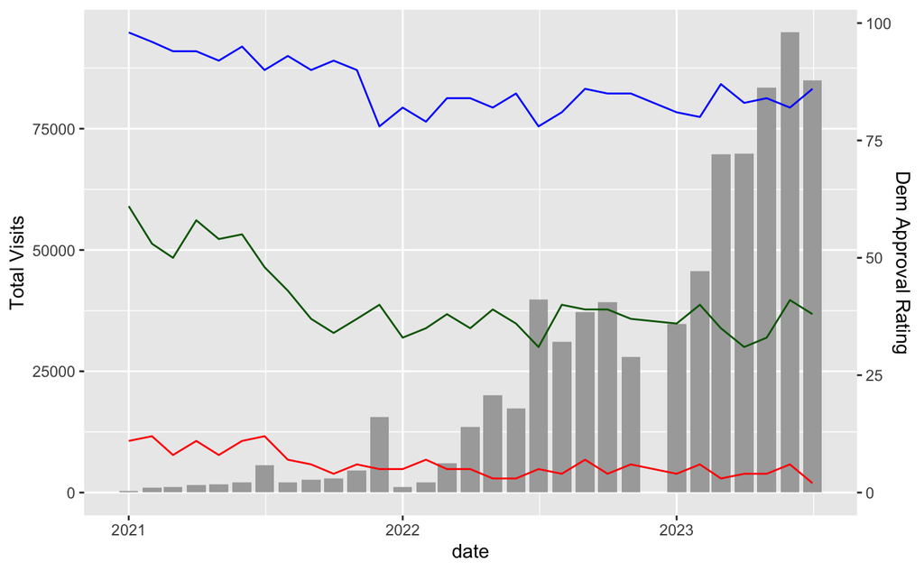

```r
#note - chatgpt wrote this code for me, I wanted to put these on the same graph but couldn't figure out the scale part
library(ggplot2)
ggplot(visits_by_month_ratings, aes(x = date)) +
  # Bar chart for total_visits
  geom_bar(aes(y = total_visits), stat = "identity", fill = "darkgray") +
  # Line graphs for approval_ratings
  geom_line(aes(y = dem_approval_pct * max(total_visits) / max(dem_approval_pct)), color = "blue") +
  geom_line(aes(y = ind_approval_pct * max(total_visits) / max(dem_approval_pct)), color = "darkgreen") +
  geom_line(aes(y = rep_approval_pct * max(total_visits) / max(dem_approval_pct)), color = "red") +
  # Y-axis scale for total_visits
  scale_y_continuous(name = "Total Visits", breaks = seq(0, 70000, by = 10000)) +
  # Secondary Y-axis scale for approval_rating
  scale_y_continuous(
    name = "Total Visits",
    sec.axis = sec_axis(~ . * max(visits_by_month_ratings$dem_approval_pct) / max(visits_by_month_ratings$total_visits), name = "Dem Approval Rating")
  ) +
  theme_gray()
```

```r
#note - not sure if this is actually a valuable graph. Should we just throw out 2021 data because it's so sparse compared to 2022/23? Does this highlight fluctuations in visits or just a lack of data for earlier months?
```

Derek’s feedback: Doesn’t seem like there’s any correlation there, but if you wanted to find out you could calculate a correlation coefficient or do a t-test (https://thescoop.org/data_journalism_book/basicstats.html)

Ok - let’s calculate the correlation coefficient to see if these are related. I think we should just look at data from 2022 and 2023 because the 2021 data is not very robust.

```r
#let's take out 2021 data
month_ratings_post_covid <- visits_by_month_ratings |> filter (date > "2021-12-31")

#now let's take out the non-numeric data

#month_ratings_dbl <- visits_by_month_ratings |>
  #select(-year, -month, -date)

#now let's run the correlation test
month_ratings_post_covid |>
  select(-year, -month, -date) |>
  correlate()
```

```
Correlation computed with
• Method: 'pearson'
• Missing treated using: 'pairwise.complete.obs'
```

| term | total_visits | rep_approval_pct | ind_approval_pct | dem_approval_pct |
| --- | --- | --- | --- | --- |
| total_visits | NA | -0.2831258 | 0.04810442 | 0.2564240 |
| rep_approval_pct | -0.28312584 | NA | 0.10937339 | -0.3582779 |
| ind_approval_pct | 0.04810442 | 0.1093734 | NA | 0.1580741 |
| dem_approval_pct | 0.25642404 | -0.3582779 | 0.15807406 | NA |

Yup, looks like there is not really a significant relationship between visits to the White House and Biden’s approval ratings for any party.

4. Who has sponsored the most White House visitors?

```r
### need to clean data in open refine :)
open_refine_cleaned_visitors <- read_csv("data/cleaned_OPENREFINE.csv")
```

```r
open_refine_cleaned_visitors |> group_by(VISITEE_NAMELAST_CLEAN, VISITEE_NAMEFIRST_CLEAN) |>
  summarise(visits = n()) |>
  arrange(desc(visits))
```

[output not shown]

5. What percent of visitors have just been labeled “office visitors”?